# SI 618: Data Manipulation and Analysis

## 05 - Correlation, Regression, and ANOVA (and a t-test) 📊📈

👤 *Instructor: Dr. Chris Teplovs*  
🏫 *School of Information, University of Michigan*  
© 2024. *This notebook may not be shared outside the course without permission.*

Version 2024.09.25.5.CT

## 📝 Outline of Today's Class

1. 📢 **Announcements**
2. ❓ **Questions about the material so far?**
3. 💻 **Coding basics**
4. 🎓 **Lecture on Correlation, Regression, and ANOVA**
5. ☕ **Break**
6. 🖥️ **Coding exercises**

## 💡 Coding Basics

### Function Parameters and Arguments

Parameters are placeholders defined in the function declaration, while arguments are the actual values passed to the function when it is called. When invoked, parameters receive arguments, allowing the function to process the provided data.

Functions can accept zero or more parameters. For example, the `print()` function can take multiple arguments. One parameter in `print()` is `end`, which defaults to `'\n'`. You can override this default by supplying a different argument to the `end` parameter.

```python
# Example with default behavior (new line after each print)
print('Hello')  # Outputs: Hello\n

# Changing the 'end' parameter to keep everything on the same line
print('Hello', end=' ')
print('World')  # Outputs: Hello World (on the same line)
```

```
Hello
Hello World
```

### Positional and Keyword Arguments

Arguments can be passed to a function either by **position** or by **keyword**.

- **Positional arguments** are assigned to parameters in the same order they appear in the function definition.
- **Keyword arguments** are assigned to parameters by name, regardless of their order.

```python
def greet(name, greeting):
    print(f'{greeting}, {name}!')

greet('Chris', 'Hello') # Positional arguments
greet(greeting='Hello', name='Chris') # Keyword arguments
greet('Chris', greeting='Hello') # Mixed arguments
```

```
Hello, Chris!
Hello, Chris!
Hello, Chris!
```

```python
#greet(name='Chris', 'Hello') # Error
```

### Default Parameter Values

In a function definition, you can assign **default values** to parameters. This makes the parameter **optional**—if no argument is provided for that parameter, the default value will be used. If a parameter doesn’t have a default value, it becomes **required** when calling the function.

```python
def greet(name, greeting='Hello'):
    print(f'{greeting}, {name}!')

greet('Chris') # Hello, Chris!
greet('Chris', 'Hi') # Hi, Chris!
```

```
Hello, Chris!
Hi, Chris!
```

### Variable-Length Argument Lists

You can define functions that accept a variable number of arguments using two constructs: `*args` and `**kwargs`.

- **`*args`** is used to pass a variable number of **positional arguments** to a function. It collects these arguments into a tuple.

```python
def add(*args):
    return sum(args)

print(add(1, 2, 3)) # 6
print(add(1, 2, 3, 4, 5)) # 15
```

```
6
15
```

The **`**kwargs`** construct is used to pass a variable number of **keyword arguments** to a function. It collects these arguments into a dictionary, where the keys are the parameter names, and the values are the arguments passed.

```python
def greet(**kwargs):
    for key, value in kwargs.items():
        print(f'{key}: {value}')

greet(name='Chris', greeting='Hello') # name: Chris, greeting: Hello
greet(name='Chris', greeting='Hello', age=21) # name: Chris, greeting: Hello, age: 21
```

```
name: Chris
greeting: Hello
name: Chris
greeting: Hello
age: 21
```

### Unpacking Argument Lists

The `*` and `**` operators can be used to **unpack** argument lists when calling a function.

- `*` unpacks positional arguments from a list or tuple.
- `**` unpacks keyword arguments from a dictionary.

```python
def add(a, b, c):
    return a + b + c
```

```python
args = [1, 2, 3]
add(*args)  # we are passing three elements as arguments to the function
```

```
6
```

```python
kwargs = {'a': 1, 'b': 2, 'c': 3}
add(**kwargs) # double asterisks to unpack the dictionary and send to the function
```

```
6
```

### 🚀 Challenge:

Write a function called `print_args` that takes a variable number of positional arguments and a variable number of keyword arguments, and prints them.

- The function should print the **positional arguments** in the order they were passed.
- It should also print the **keyword arguments** in the order they were passed.
- The function should return the number of positional arguments and the number of keyword arguments passed to it.

**Test your function** with a variety of positional and keyword arguments to ensure it works correctly.

```python
def print_args(*args, **kwargs):
    """Print the positional arguments and keyword arguments. Return the number of arguments passed."""
    for arg in args:
        print(arg)
    for key, value in kwargs.items():
        print(f'{key}: {value}')
    return len(args), len(kwargs)

print_args(1, 2, 3, name='Chris', age=21)
```

```
1
2
3
name: Chris
age: 21
```

```
(3, 2)
```

### ⚡ Lambda Functions

Lambda functions are small, **anonymous** functions that can take any number of parameters but are limited to a single expression. These functions are defined using the `lambda` keyword.

```python
add = lambda a, b: a + b
add(1, 2)
```

```
3
```

## 📉 Correlation does not imply causation!

[figure not shown]

```python
import pandas as pd
import numpy as np
import matplotlib.pyplot as plt
import seaborn as sns
```

## 🍷 Wine Quality Dataset

[Explore the Wine Quality Dataset](https://www.kaggle.com/uciml/red-wine-quality-cortez-et-al-2009/home)

Let's load the wine quality dataset:

```python
wine = pd.read_csv('https://raw.githubusercontent.com/umsi-data-science/si370/master/data/winequality-red.csv')
wine.head()
```

|  | fixed acidity | volatile acidity | citric acid | residual sugar | chlorides | free sulfur dioxide | total sulfur dioxide | density | pH | sulphates | alcohol | quality |
| --- | --- | --- | --- | --- | --- | --- | --- | --- | --- | --- | --- | --- |
| 0 | 7.4 | 0.70 | 0.00 | 1.9 | 0.076 | 11.0 | 34.0 | 0.9978 | 3.51 | 0.56 | 9.4 | 5 |
| 1 | 7.8 | 0.88 | 0.00 | 2.6 | 0.098 | 25.0 | 67.0 | 0.9968 | 3.20 | 0.68 | 9.8 | 5 |
| 2 | 7.8 | 0.76 | 0.04 | 2.3 | 0.092 | 15.0 | 54.0 | 0.9970 | 3.26 | 0.65 | 9.8 | 5 |
| 3 | 11.2 | 0.28 | 0.56 | 1.9 | 0.075 | 17.0 | 60.0 | 0.9980 | 3.16 | 0.58 | 9.8 | 6 |
| 4 | 7.4 | 0.70 | 0.00 | 1.9 | 0.076 | 11.0 | 34.0 | 0.9978 | 3.51 | 0.56 | 9.4 | 5 |

We can create a pairplot for the wine dataset:

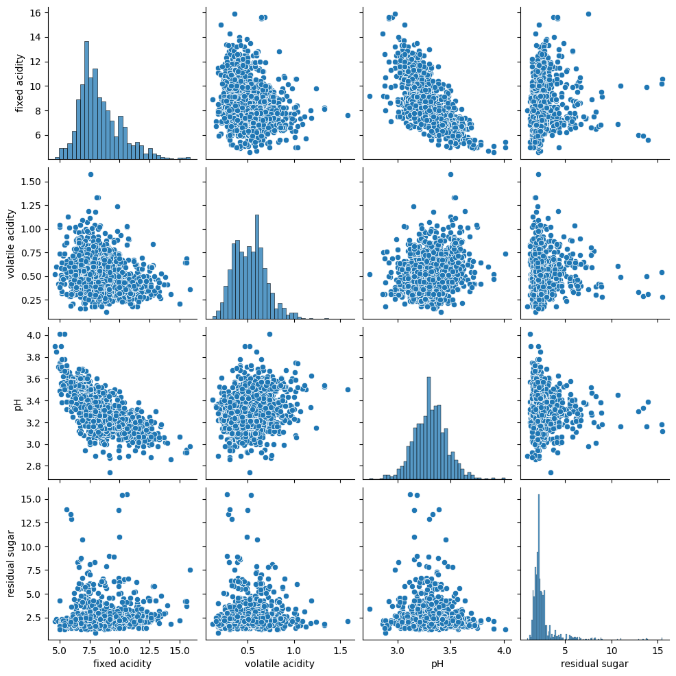

```python
sns.pairplot(wine,vars = ['fixed acidity','volatile acidity','pH','residual sugar'])
```

## 📊 Correlation

We can also explore the correlation between variables. According to [Wikipedia](https://en.wikipedia.org/wiki/Correlation_and_dependence):

> In the broadest sense, correlation is any statistical association, though in common usage, it most often refers to how close two variables are to having a linear relationship with each other... Correlations are useful because they can indicate a predictive relationship that can be exploited in practice.

The correlation coefficient can range from -1 to 1 and represents the degree and direction of the relationship between two variables.

- A coefficient of **-1** indicates a perfect negative correlation.
- A coefficient of **0** indicates no correlation.
- A coefficient of **1** indicates a perfect positive correlation.

Here’s a visualization of a range of correlation coefficients:

[figure not shown]

## Calculating (Pearson's) Correlation Coefficients

(Adapted from [Cuemath](https://www.cuemath.com/data/how-to-calculate-correlation-coefficient/))

$\rho_{xy}$ = $\text{Cov}(x,y) \over (\sigma_x \sigma_y)$

where Cov $(x,y)$ is the covariance of $x$ and $y$ and $\sigma_x$ and $\sigma_y$ are the standard deviations of $x$ and $y$. The covariance is defined as:

$\text{Cov}(x,y) = { {\sum_{i=1}^n (x_i - \bar{x})(y_i - \bar{y})} \over n}$

where $\bar{x}$ and $\bar{y}$ are the means of $x$ and $y$.

The correlation coefficient may be calculated accoring to the formula:

$r = \frac{\sum_{i=1}^n (x_i - \bar{x})(y_i - \bar{y})}{\sqrt{\sum_{i=1}^n (x_i - \bar{x})^2} \sqrt{\sum_{i=1}^n (y_i - \bar{y})^2}}$

where $x_i$ and $y_i$ are the individual values of $x$ and $y$ and $\bar{x}$ and $\bar{y}$ are the means of $x$ and $y$. The formula can also be expressed as:

$r = \frac{n \sum_{i=1}^n x_i y_i - \sum_{i=1}^n x_i \sum_{i=1}^n y_i}{\sqrt{n \sum_{i=1}^n x_i^2 - (\sum_{i=1}^n x_i)^2} \sqrt{n \sum_{i=1}^n y_i^2 - (\sum_{i=1}^n y_i)^2}}$

```python
# to calculate all possible correlation coefficients in a DataFrame
wine.corr()
```

|  | fixed acidity | volatile acidity | citric acid | residual sugar | chlorides | free sulfur dioxide | total sulfur dioxide | density | pH | sulphates | alcohol | quality |
| --- | --- | --- | --- | --- | --- | --- | --- | --- | --- | --- | --- | --- |
| fixed acidity | 1.000000 | -0.256131 | 0.671703 | 0.114777 | 0.093705 | -0.153794 | -0.113181 | 0.668047 | -0.682978 | 0.183006 | -0.061668 | 0.124052 |
| volatile acidity | -0.256131 | 1.000000 | -0.552496 | 0.001918 | 0.061298 | -0.010504 | 0.076470 | 0.022026 | 0.234937 | -0.260987 | -0.202288 | -0.390558 |
| citric acid | 0.671703 | -0.552496 | 1.000000 | 0.143577 | 0.203823 | -0.060978 | 0.035533 | 0.364947 | -0.541904 | 0.312770 | 0.109903 | 0.226373 |
| residual sugar | 0.114777 | 0.001918 | 0.143577 | 1.000000 | 0.055610 | 0.187049 | 0.203028 | 0.355283 | -0.085652 | 0.005527 | 0.042075 | 0.013732 |
| chlorides | 0.093705 | 0.061298 | 0.203823 | 0.055610 | 1.000000 | 0.005562 | 0.047400 | 0.200632 | -0.265026 | 0.371260 | -0.221141 | -0.128907 |
| free sulfur dioxide | -0.153794 | -0.010504 | -0.060978 | 0.187049 | 0.005562 | 1.000000 | 0.667666 | -0.021946 | 0.070377 | 0.051658 | -0.069408 | -0.050656 |
| total sulfur dioxide | -0.113181 | 0.076470 | 0.035533 | 0.203028 | 0.047400 | 0.667666 | 1.000000 | 0.071269 | -0.066495 | 0.042947 | -0.205654 | -0.185100 |
| density | 0.668047 | 0.022026 | 0.364947 | 0.355283 | 0.200632 | -0.021946 | 0.071269 | 1.000000 | -0.341699 | 0.148506 | -0.496180 | -0.174919 |
| pH | -0.682978 | 0.234937 | -0.541904 | -0.085652 | -0.265026 | 0.070377 | -0.066495 | -0.341699 | 1.000000 | -0.196648 | 0.205633 | -0.057731 |
| sulphates | 0.183006 | -0.260987 | 0.312770 | 0.005527 | 0.371260 | 0.051658 | 0.042947 | 0.148506 | -0.196648 | 1.000000 | 0.093595 | 0.251397 |
| alcohol | -0.061668 | -0.202288 | 0.109903 | 0.042075 | -0.221141 | -0.069408 | -0.205654 | -0.496180 | 0.205633 | 0.093595 | 1.000000 | 0.476166 |
| quality | 0.124052 | -0.390558 | 0.226373 | 0.013732 | -0.128907 | -0.050656 | -0.185100 | -0.174919 | -0.057731 | 0.251397 | 0.476166 | 1.000000 |

A **heatmap** is a highly useful visualization technique for large correlation matrices. It helps in quickly identifying patterns and the strength of relationships between multiple variables in a dataset.

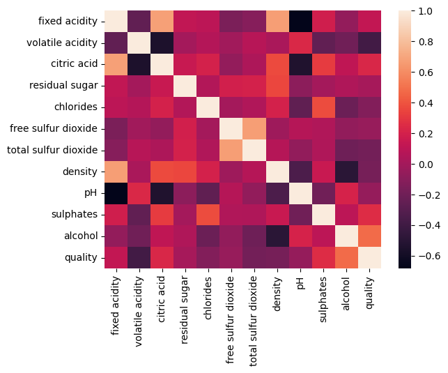

```python
sns.heatmap(wine.corr())  # do not use this simple form in any of your work!
```

The choice of color palette for heatmaps is crucial. We should use a **diverging color map** that has appropriate "end" points and a neutral "center" point.

For more information, check out this resource: [Diverging Color Palettes](https://seaborn.pydata.org/tutorial/color_palettes.html#diverging-color-palettes).

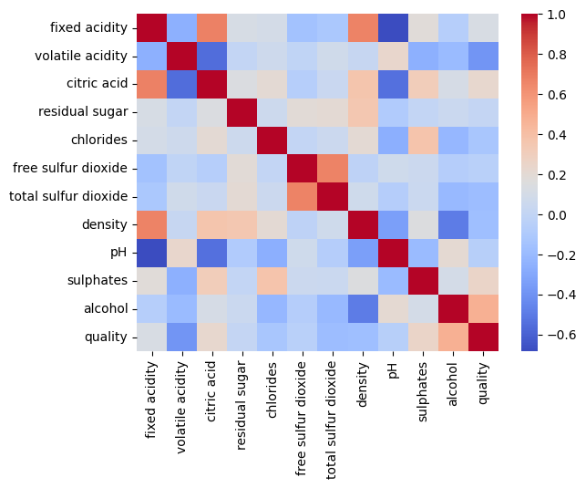

```python
sns.heatmap(wine.corr(),cmap="coolwarm") # better, but still not great
```

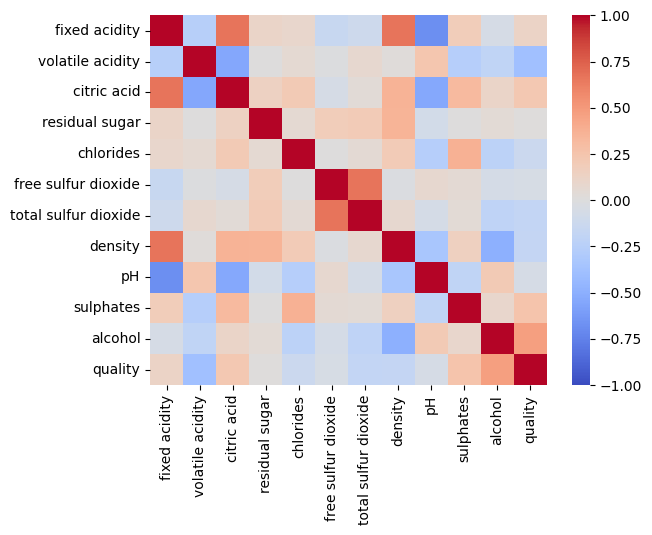

```python
sns.heatmap(wine.corr(),cmap="coolwarm",vmax=1,vmin=-1)
```

We can **annotate** the heatmap with the correlation coefficients. This can be a bit tricky because we want to:

1. Center the annotations within each cell.
2. Use a different color for the annotations.

To achieve this:

- Use the `fmt` parameter in `heatmap` to format the annotations.
- Use the `annot_kws` parameter in `heatmap` to specify the font size and color for the annotations.

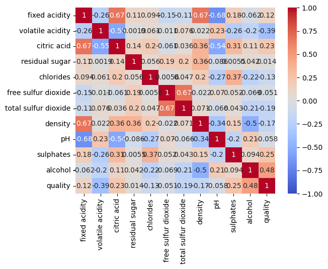

```python
sns.heatmap(wine.corr(),cmap="coolwarm",vmax=1,vmin=-1,annot=True) # more info, but difficult to read
```

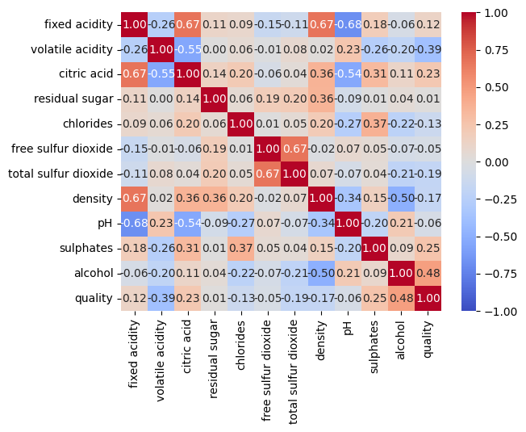

```python
sns.heatmap(wine.corr(),cmap="coolwarm",vmax=1,vmin=-1,annot=True, fmt=".2f")
```

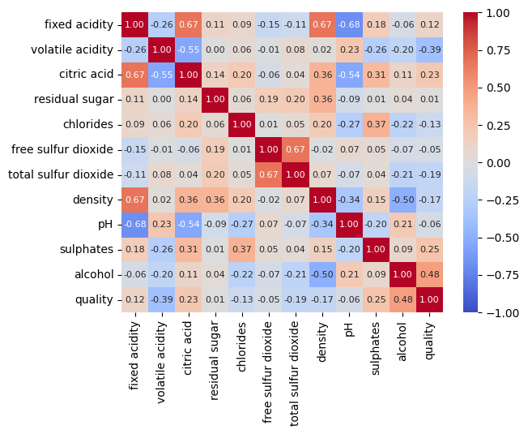

```python
# a nicely tuned heatmap
sns.heatmap(wine.corr(),cmap="coolwarm",vmax=1,vmin=-1,annot=True, fmt=".2f", annot_kws={"size": 8})
# annot_kws is the keyword arguments for the annotations
```

Recall that we used **JointGrid** to create a combination of a `regplot` and a `histplot` on the same plot. Let's take a closer look at how that works:

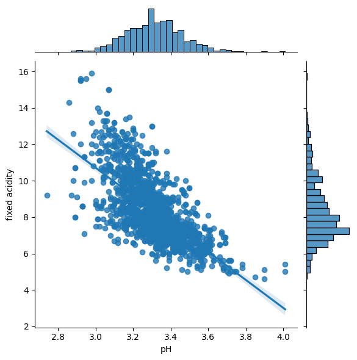

```python
g = sns.JointGrid(data=wine,x='pH',y='fixed acidity')
g = g.plot(sns.regplot, sns.histplot)
```

## Ordinary Least Squares (OLS) Regression

We can gain much more detailed insights into the regression model by using the `statsmodels` library.

```python
import statsmodels.api as sm
import statsmodels.formula.api as smf
```

Recall that **linear regression** aims to express the relationship between two variables as a linear combination:

$y = \beta_0 + \beta_1 x + \epsilon$

Where:

- $y$ is the **dependent variable**,
- $x$ is the **independent variable**,
- $\beta_0$ is the **intercept**,
- $\beta_1$ is the **slope**,
- $\epsilon$ is the **error term** (the difference between the observed value of $y$ and the predicted value by the model).

The error term is assumed to be normally distributed with a mean of 0 and constant variance.

The goal of linear regression is to find the values of $\beta_0$ and $\beta_1$ that minimize the sum of the squared errors, a method known as the **ordinary least squares (OLS) criterion**.

We can use the sums of squared terms to calculate the slope and intercept:

$\beta_1 = \frac{\sum_{i=1}^n (x_i - \bar{x})(y_i - \bar{y})}{\sum_{i=1}^n (x_i - \bar{x})^2}$

$\beta_0 = \bar{y} - \beta_1 \bar{x}$

where $\bar{x}$ and $\bar{y}$ are the means of $x$ and $y$.

Expressed differently:

$\beta_1 = \frac{n \sum_{i=1}^n x_i y_i - \sum_{i=1}^n x_i \sum_{i=1}^n y_i}{n \sum_{i=1}^n x_i^2 - (\sum_{i=1}^n x_i)^2}$

We can use the `statsmodels` library to perform **OLS regression**. The `statsmodels` library offers a formulaic interface for linear regression, similar to that in R. This allows us to specify the regression model using a simple string like:

`'dependent_variable ~ independent_variable'`

```python
model0 = smf.ols("pH ~ Q('fixed acidity')", data=wine).fit() # Q() is used to handle column names with spaces
model0.summary()
```

OLS Regression Results

| Dep. Variable: | pH | R-squared: | 0.466 |
| --- | --- | --- | --- |
| Model: | OLS | Adj. R-squared: | 0.466 |
| Method: | Least Squares | F-statistic: | 1396. |
| Date: | Thu, 26 Sep 2024 | Prob (F-statistic): | 4.06e-220 |
| Time: | 15:35:39 | Log-Likelihood: | 1221.3 |
| No. Observations: | 1599 | AIC: | -2439. |
| Df Residuals: | 1597 | BIC: | -2428. |
| Df Model: | 1 |  |  |
| Covariance Type: | nonrobust |  |  |

|  | coef | std err | t | P>\|t\| | [0.025 | 0.975] |
| --- | --- | --- | --- | --- | --- | --- |
| Intercept | 3.8150 | 0.014 | 276.927 | 0.000 | 3.788 | 3.842 |
| Q('fixed acidity') | -0.0606 | 0.002 | -37.366 | 0.000 | -0.064 | -0.057 |

| Omnibus: | 58.659 | Durbin-Watson: | 1.655 |
| --- | --- | --- | --- |
| Prob(Omnibus): | 0.000 | Jarque-Bera (JB): | 143.337 |
| Skew: | -0.155 | Prob(JB): | 7.49e-32 |
| Kurtosis: | 4.434 | Cond. No. | 42.1 |

Notes:  
[1] Standard Errors assume that the covariance matrix of the errors is correctly specified.

In the above example, the $r^2$ value is **0.466**, indicating that the model explains about **46.6%** of the variance (which isn't bad).

Additionally, the model is statistically significant, as the p-value (referred to as "Prob (F-statistic)" in the output) is less than **0.05**. The parameter estimates are also statistically significant, meaning we can use the following equation to predict the value of pH based on fixed acidity:

`pH = 3.8150 + (-0.0606) * fixed acidity`

or

`pH = 3.8150 - 0.0606 * fixed acidity`

We can assess the **goodness of fit** of the model in several ways:

- One method is to examine the **residuals** (the difference between the observed and predicted values).
  - The `residplot` function can be used to plot residuals against predicted values (note that `residplot` is essentially a shortcut for an annotated scatterplot).
- The `qqplot` function can be used to plot the residuals against a normal distribution.
- The `influence_plot` function helps visualize the **leverage** of each observation.
- The `plot_regress_exog` function plots the regression results for each independent variable.

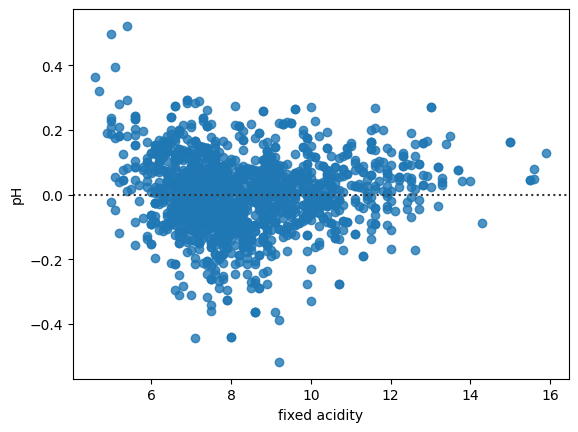

```python
residplot = sns.residplot(x='fixed acidity',y='pH',data=wine)
```

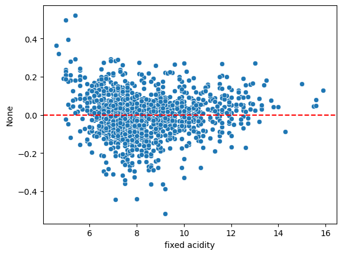

```python
sns.scatterplot(x=wine['fixed acidity'],y=model0.resid)
plt.axhline(0, color='r', linestyle='--')
plt.show()
```

We can examine the **distribution of residuals** to check if they are normally distributed. This is crucial because the OLS regression model assumes normality of residuals, and verifying this helps ensure that the assumption is met.

To visualize the distribution of residuals, we can use a **histogram**.

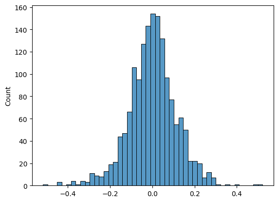

```python
sns.histplot(model0.resid)
```

We can also use a **Q-Q plot** to check the normality of residuals. A Q-Q plot compares the quantiles of the residuals with the quantiles of a normal distribution.

If the residuals are normally distributed, the points in the Q-Q plot will fall along a straight line. We can create a Q-Q plot using the `qqplot` function from `statsmodels.graphics.gofplots`.

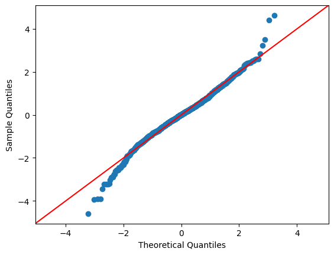

```python
from statsmodels.graphics.gofplots import qqplot
_ = qqplot(model0.resid, line='45', fit=True)
```

## 🚨 Outlier Detection

"**Outlier detection**" refers to identifying points that are extreme in value. These points may or may not influence the regression analysis.

- **Outlier**: A point with a large residual (i.e., big differences in the vertical dimension).
- **Leverage point**: A point with an extreme value of the predictor variable (i.e., big differences in the horizontal dimension).
- **Influence point**: A point where removing the observation substantially changes the estimate of the coefficients.

Consider the following cases, drawn from:

[Linear Regression in Python: Outliers & Leverage Detection](http://songhuiming.github.io/pages/2016/11/27/linear-regression-in-python-outliers-leverage-detect/)

In the first case, there are no notable points:

```python
np.random.seed(0) # seed the random number generator so we always get the same results
x1 = np.random.normal(20, 3, 20)    # create a random normal distribution of 20 points,
                                    # centered on 20, standard deviation of 20
y0 = 5 + 0.5 * x1 # create a corresponding y variable that is exactly 5 + 0.5 * x
y1 = 5 + 0.5 * x1 + np.random.normal(0, 1, 20)  # create a corresponding y variable that is 5 + 0.5 * x
                                                # plus some random noise drawn from a normal distribution
demo = pd.DataFrame({'x1':x1, 'y0':y0, 'y1':y1})
demo.head()
```

|  | x1 | y0 | y1 |
| --- | --- | --- | --- |
| 0 | 25.292157 | 17.646079 | 15.093089 |
| 1 | 21.200472 | 15.600236 | 16.253854 |
| 2 | 22.936214 | 16.468107 | 17.332543 |
| 3 | 26.722680 | 18.361340 | 17.619175 |
| 4 | 25.602674 | 17.801337 | 20.071092 |

```python
lm = sm.OLS(y1, sm.add_constant(x1)).fit()
lm1 = smf.ols("y1 ~ x1", data=demo).fit()
print("The rsquared value is " + str(lm.rsquared))
```

```
The rsquared value is 0.5759696028216694
```

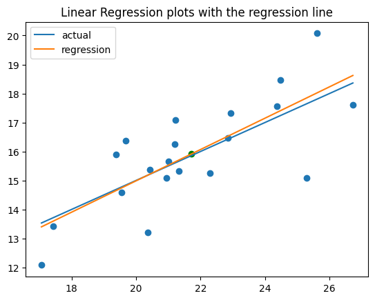

```python
plt.scatter(np.sort(demo.x1), demo.y1[np.argsort(demo.x1)])
plt.scatter(np.mean(demo.x1), np.mean(demo.y1), color = "green")
plt.plot(np.sort(demo.x1), demo.y0[np.argsort(demo.x1)], label = "actual")
plt.plot(np.sort(demo.x1), lm.predict()[np.argsort(demo.x1)], label = "regression")
plt.title("Linear Regression plots with the regression line")
plt.legend()
```

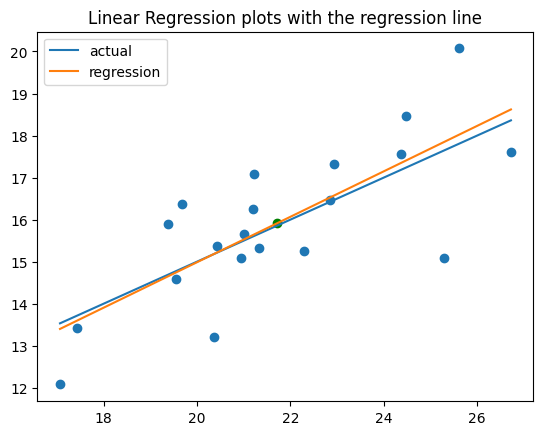

```python
# equivalently, without using DataFrames
plt.scatter(np.sort(x1), y1[np.argsort(x1)])
plt.scatter(np.mean(x1), np.mean(y1), color = "green")
plt.plot(np.sort(x1), y0[np.argsort(x1)], label = "actual")
plt.plot(np.sort(x1), lm.predict()[np.argsort(x1)], label = "regression")
plt.title("Linear Regression plots with the regression line")
plt.legend()
```

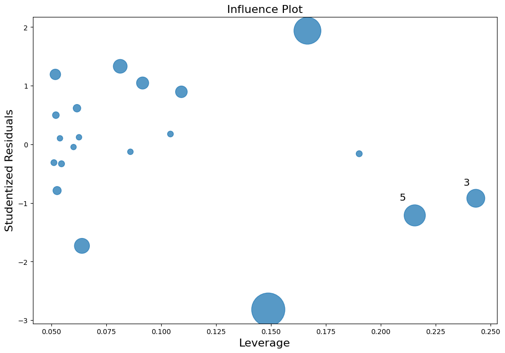

```python
fig, ax = plt.subplots(figsize=(12,8))
fig = sm.graphics.influence_plot(lm, alpha  = 0.00005, ax = ax, criterion="cooks")
```

High leverage point, no outliers

```
The rsquared value is 0.6835270587597562
```

```
[]
```

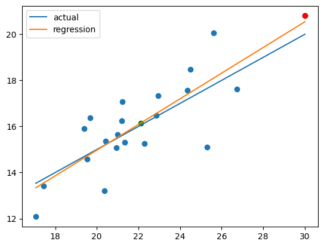

```python
x2 = np.r_[x1, 30]
y2 = np.r_[y1, 20.8]
y20 = np.r_[y0, 20]

lm2 = sm.OLS(y2, sm.add_constant(x2)).fit()
print("The rsquared value is " + str(lm2.rsquared))

plt.scatter(np.sort(x2), y2[np.argsort(x2)])
plt.scatter(30, 20.8, color = "red")
plt.scatter(np.mean(x2), np.mean(y2), color = "green")
plt.plot(np.sort(x2), y20[np.argsort(x2)], label = "actual")
plt.plot(np.sort(x2), lm2.predict()[np.argsort(x2)], label = "regression")
plt.legend()
plt.plot()
```

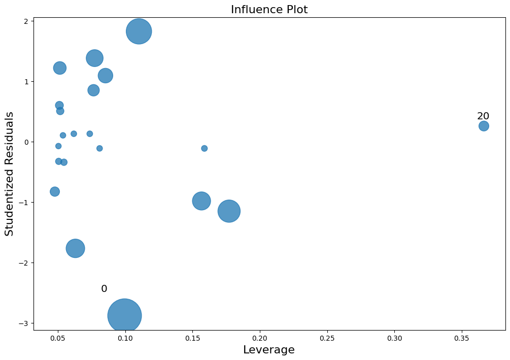

```python
fig, ax = plt.subplots(figsize=(12,8))
fig = sm.graphics.influence_plot(lm2, ax= ax, criterion="cooks")
```

Outlier, no leverage

```
The rsquared value is 0.27377526628015136
```

```
[]
```

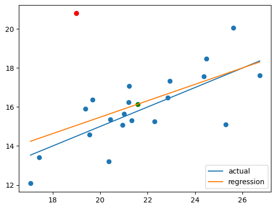

```python
x3 = np.r_[x1, 19]
y3 = np.r_[y1, 20.8]
y30 = np.r_[y0, 5 + .5 * 19]

lm3 = sm.OLS(y3, sm.add_constant(x3)).fit()
print("The rsquared value is " + str(lm3.rsquared))

plt.scatter(np.sort(x3), y3[np.argsort(x3)])
plt.scatter(19, 20.8, color = "red")
plt.scatter(np.mean(x3), np.mean(y3), color = "green")
plt.plot(np.sort(x3), y30[np.argsort(x3)], label = "actual")
plt.plot(np.sort(x3), lm3.predict()[np.argsort(x3)], label = "regression")
plt.legend()
plt.plot()
```

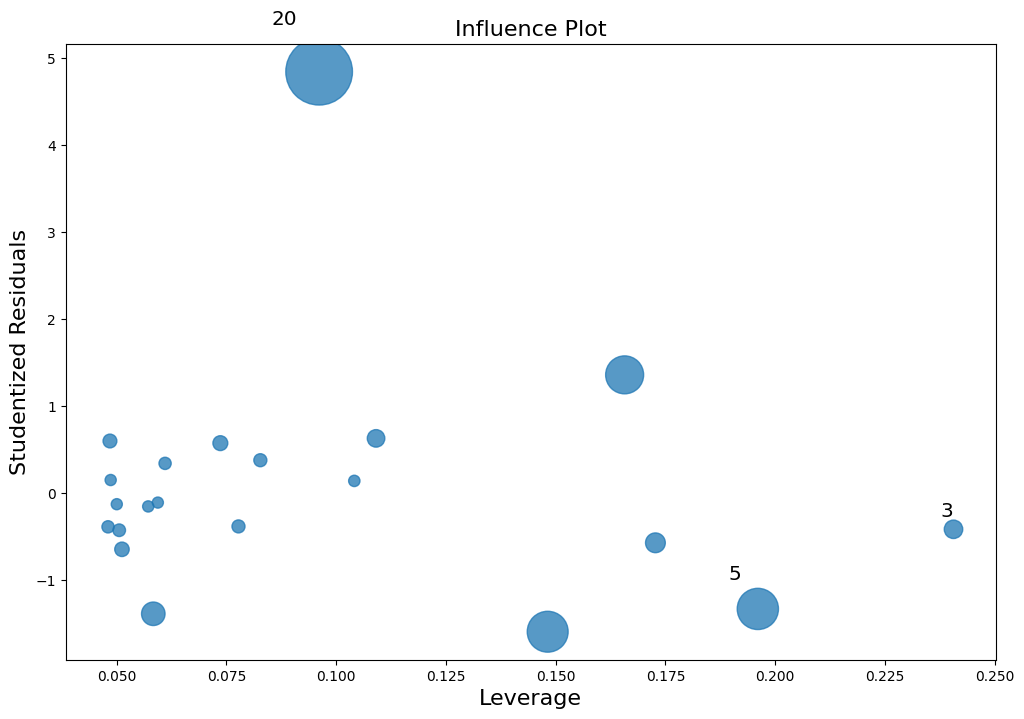

```python
fig, ax = plt.subplots(figsize=(12,8))
fig = sm.graphics.influence_plot(lm3, ax= ax, criterion="cooks")
```

Outlier and leverage point

```
The rsquared value is 0.028865535723009983
```

```
[]
```

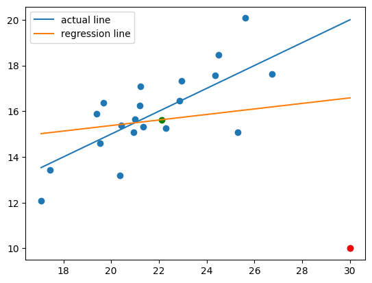

```python
x4 = np.r_[x1, 30]
y4 = np.r_[y1, 10]
y40 = np.r_[y0, 20]

lm4 = sm.OLS(y4, sm.add_constant(x4)).fit()
print("The rsquared value is " + str(lm4.rsquared))

plt.scatter(np.sort(x4), y4[np.argsort(x4)])
plt.scatter(30, 10, color = "red")
plt.scatter(np.mean(x4), np.mean(y4), color = "green")
plt.plot(np.sort(x4), y40[np.argsort(x4)], label = "actual line")
plt.plot(np.sort(x4), lm4.predict()[np.argsort(x4)], label = "regression line")
plt.legend()
plt.plot()
```

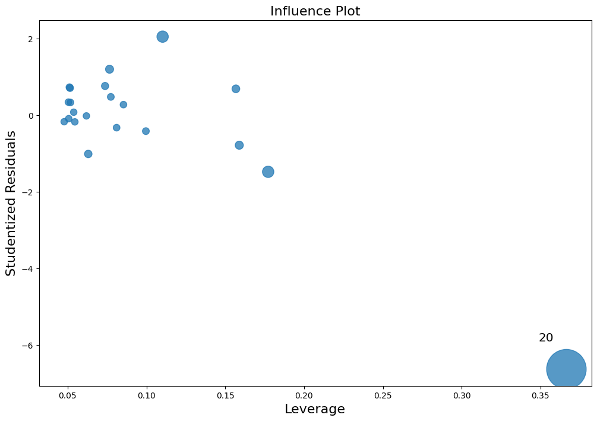

```python
fig, ax = plt.subplots(figsize=(12,8))
fig = sm.graphics.influence_plot(lm4, ax= ax, criterion="cooks")
```

Let's look at Anscombe's Quartet:

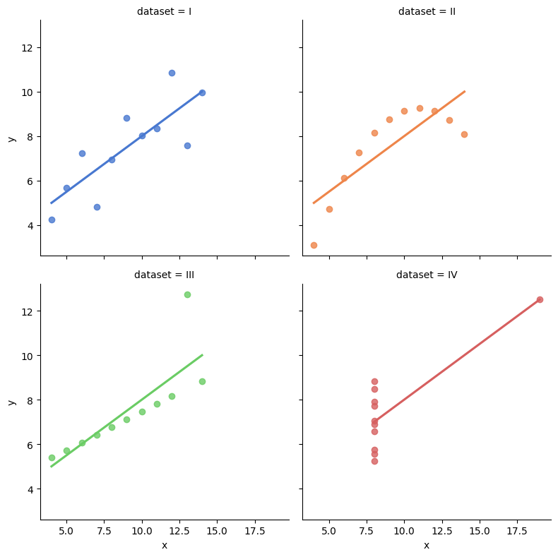

```python
anscombe = sns.load_dataset("anscombe")

# Show the results of a linear regression within each dataset
sns.lmplot(x="x", y="y", col="dataset", hue="dataset", data=anscombe,
           col_wrap=2, ci=None, palette="muted", height=4)
```

```python
anscombe.sample(10)
```

|  | dataset | x | y |
| --- | --- | --- | --- |
| 29 | III | 4.0 | 5.39 |
| 37 | IV | 8.0 | 8.47 |
| 10 | I | 5.0 | 5.68 |
| 31 | III | 7.0 | 6.42 |
| 8 | I | 12.0 | 10.84 |
| 27 | III | 14.0 | 8.84 |
| 22 | III | 10.0 | 7.46 |
| 7 | I | 4.0 | 4.26 |
| 39 | IV | 8.0 | 5.25 |
| 34 | IV | 8.0 | 5.76 |

```python
anscombe_1 = anscombe[anscombe.dataset == 'I']
anscombe_2 = anscombe[anscombe.dataset == 'II']
anscombe_3 = anscombe[anscombe.dataset == 'III']
anscombe_4 = anscombe[anscombe.dataset == 'IV']
```

```
The rsquared value is 0.666542459508775
```

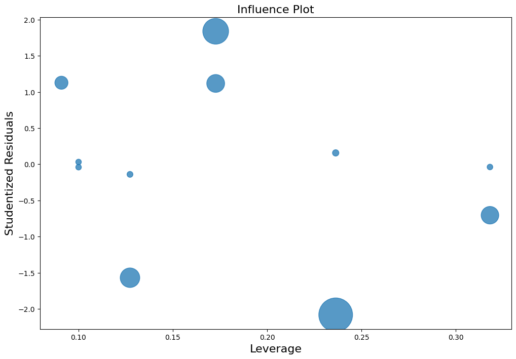

```python
anscombe_1_lm = smf.ols('y ~ x',anscombe_1).fit()
print("The rsquared value is " + str(anscombe_1_lm.rsquared))
fig, ax = plt.subplots(figsize=(12,8))
fig = sm.graphics.influence_plot(anscombe_1_lm, ax= ax, criterion="cooks",alpha=0.05)
```

```
The rsquared value is 0.6662420337274844
```

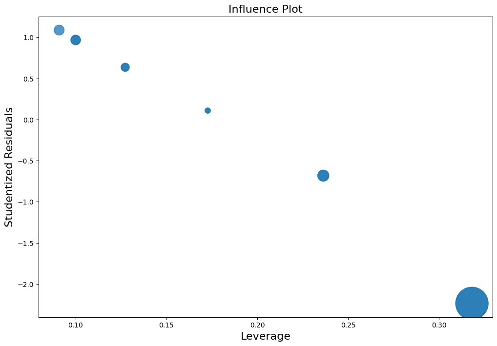

```python
anscombe_2_lm = smf.ols('y ~ x',anscombe_2).fit()
print("The rsquared value is " + str(anscombe_2_lm.rsquared))
fig, ax = plt.subplots(figsize=(12,8))
fig = sm.graphics.influence_plot(anscombe_2_lm, ax= ax, criterion="cooks",alpha=.05)
```

```
The rsquared value is 0.6663240410665594
```

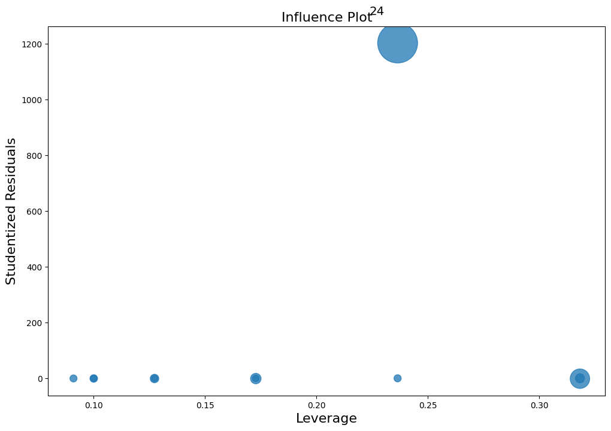

```python
anscombe_3_lm = smf.ols('y ~ x',anscombe_3).fit()
print("The rsquared value is " + str(anscombe_3_lm.rsquared))
fig, ax = plt.subplots(figsize=(12,8))
fig = sm.graphics.influence_plot(anscombe_3_lm, ax= ax, criterion="cooks",alpha=0.05)
```

```python
anscombe_4.head(10)
```

|  | dataset | x | y |
| --- | --- | --- | --- |
| 33 | IV | 8.0 | 6.58 |
| 34 | IV | 8.0 | 5.76 |
| 35 | IV | 8.0 | 7.71 |
| 36 | IV | 8.0 | 8.84 |
| 37 | IV | 8.0 | 8.47 |
| 38 | IV | 8.0 | 7.04 |
| 39 | IV | 8.0 | 5.25 |
| 40 | IV | 19.0 | 12.50 |
| 41 | IV | 8.0 | 5.56 |
| 42 | IV | 8.0 | 7.91 |

```
The rsquared value is 0.6667072568984653
```

[figure not shown]

```python
anscombe_4_lm = smf.ols('y ~ x',anscombe_4).fit()
print("The rsquared value is " + str(anscombe_4_lm.rsquared))
fig, ax = plt.subplots(figsize=(12,8))
# note that the following line will result in warnings about the data
fig = sm.graphics.influence_plot(anscombe_4_lm, ax= ax, criterion="cooks",alpha=0.05)
```

```python
infl = anscombe_3_lm.get_influence()
sm_fr = infl.summary_frame()
sm_fr
```

|  | dfb_Intercept | dfb_x | cooks_d | standard_resid | hat_diag | dffits_internal | student_resid | dffits |
| --- | --- | --- | --- | --- | --- | --- | --- | --- |
| 22 | -0.004626 | -4.412673e-02 | 0.011765 | -0.460177 | 0.100000 | -0.153392 | -0.439055 | -0.146352 |
| 23 | -0.037133 | 1.864368e-02 | 0.002141 | -0.196333 | 0.100000 | -0.065444 | -0.185502 | -0.061834 |
| 24 | -357.909597 | 5.252677e+02 | 1.392849 | 2.999992 | 0.236364 | 1.669041 | 1203.539464 | 669.587544 |
| 25 | -0.032900 | -8.934283e-16 | 0.005473 | -0.330851 | 0.090909 | -0.104624 | -0.313844 | -0.099246 |
| 26 | 0.049155 | -1.172274e-01 | 0.025984 | -0.596951 | 0.127273 | -0.227964 | -0.574295 | -0.219312 |
| 27 | 0.489742 | -6.674064e-01 | 0.300571 | -1.134972 | 0.318182 | -0.775333 | -1.155982 | -0.789686 |
| 28 | 0.027001 | -2.088417e-02 | 0.000518 | 0.070416 | 0.172727 | 0.032176 | 0.066407 | 0.030344 |
| 29 | 0.240903 | -2.089150e-01 | 0.033817 | 0.380699 | 0.318182 | 0.260067 | 0.361851 | 0.247192 |
| 30 | 0.137434 | -2.313597e-01 | 0.059536 | -0.755177 | 0.172727 | -0.345068 | -0.735677 | -0.336158 |
| 31 | -0.019702 | 1.342485e-02 | 0.000355 | -0.069739 | 0.127273 | -0.026632 | -0.065768 | -0.025116 |
| 32 | 0.105366 | -8.740210e-02 | 0.006948 | 0.211881 | 0.236364 | 0.117880 | 0.200263 | 0.111416 |

We can also extract the Cook's Distance values and their associated p-values from the influence object:

```python
c,p = infl.cooks_distance
```

and create a DataFrame with the results

```python
df = pd.DataFrame.from_dict({'cooks_distance':c,'pvalue':p})
df
```

|  | cooks_distance | pvalue |
| --- | --- | --- |
| 0 | 0.011765 | 0.988319 |
| 1 | 0.002141 | 0.997861 |
| 2 | 1.392849 | 0.297161 |
| 3 | 0.005473 | 0.994545 |
| 4 | 0.025984 | 0.974424 |
| 5 | 0.300571 | 0.747547 |
| 6 | 0.000518 | 0.999483 |
| 7 | 0.033817 | 0.966870 |
| 8 | 0.059536 | 0.942570 |
| 9 | 0.000355 | 0.999645 |
| 10 | 0.006948 | 0.993082 |

Note that we could sort the above in various, helpful ways.

## ANOVA (Analysis of Variance)

ANOVA, or **ANalysis Of VAriance**, is a statistical method used to compare the means of three or more groups to see if they are significantly different from each other.

```python
import statsmodels.api as sm
from statsmodels.formula.api import ols
```

## 🍕 Pizza Dough Recipes

(Adapted from [DASL](https://dasl.datadescription.com/datafile/activating-baking-yeast/?_sfm_methods=Analysis+of+Variance&_sfm_cases=4+59943))

> To shorten the time it takes to make his favorite pizza, a student designed an experiment to test the effect of sugar and milk on the activation times for baking yeast. Specifically, he tested four different recipes and measured how many seconds it took for the same amount of dough to rise to the top of a bowl. He randomized the order of the recipes and replicated each treatment 4 times.

Let's go ahead and read in the `data/activating-baking-yeast.txt` file into a DataFrame called `yeast`.

```python
yeast = pd.read_csv('https://raw.githubusercontent.com/umsi-data-science/si370/master/data/activating-baking-yeast.txt',sep='\t')
```

As usual, inspect the DataFrame so we know what we're dealing with:

```python
yeast.head()
```

|  | Activation Times | Recipe |
| --- | --- | --- |
| 0 | 575 | A |
| 1 | 395 | A |
| 2 | 280 | B |
| 3 | 120 | B |
| 4 | 720 | C |

```python
yeast.columns
```

```
Index(['Activation Times', 'Recipe '], dtype='object')
```

Those column names aren't nice to work with, so let's go ahead and rename them to `activation` and `recipe`

```python
to_be_renamed = {"Activation Times" :"activation", "Recipe ": "recipe"}
yeast = yeast.rename(columns = to_be_renamed)
```

```python
yeast.head()
```

|  | activation | recipe |
| --- | --- | --- |
| 0 | 575 | A |
| 1 | 395 | A |
| 2 | 280 | B |
| 3 | 120 | B |
| 4 | 720 | C |

Let's start by visually examining our data:

#### 🚀 Challenge:

Consider the following boxplot. What can you infer about the effect of the recipe on the activation times for baking yeast?

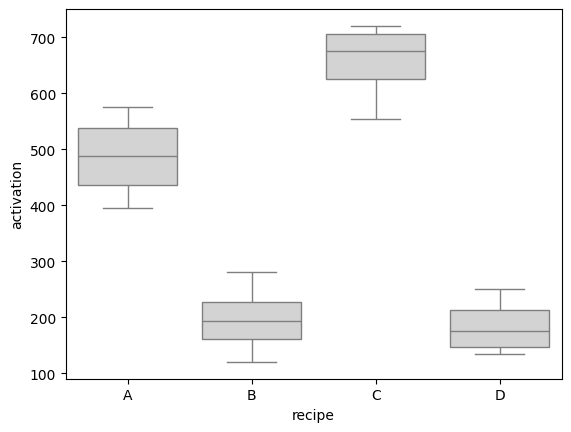

```python
sns.boxplot(x="recipe",y="activation", data=yeast, color = "lightgray")
```

1. Recipe C appears to yield the slowest activation times, as evidenced by the highest median.
2. Recipe B and Recipe D show faster activation times compared to Recipes A and C.
3. There is no significant difference in activation times between Recipes B and D.

## Let's Do an ANOVA!

We want to know if the differences in activation times between the recipes are statistically significant. In other words, do the activation times vary based on the recipes?

We can use **ANOVA** to test this. The hypotheses are:

- **Null hypothesis**: The means of the groups are equal.
- **Alternative hypothesis**: At least one group mean is different from the others.

We will use `statsmodels.formula.api` to create the model in a **readable** way. For example, `activation ~ recipe` specifies that we are modeling activation times based on recipes.

Next, we will create a model, fit it to the data, and examine the results.

```python
yeast_lm = ols('activation ~ recipe', data=yeast).fit()
table = sm.stats.anova_lm(yeast_lm, typ=2) # Type 2 ANOVA DataFrame
table
```

|  | sum_sq | df | F | PR(>F) |
| --- | --- | --- | --- | --- |
| recipe | 638967.6875 | 3.0 | 44.739175 | 8.639741e-07 |
| Residual | 57128.2500 | 12.0 | NaN | NaN |

A note about that `"typ=2"` (Adapted from [R-Bloggers](https://www.r-bloggers.com/2011/03/anova-%E2%80%93-type-iiiiii-ss-explained/)):

> NOTE: when data is balanced, the factors are orthogonal, and types I, II, and III all give the same results.

**Summary**: Typically, the hypothesis of interest is about the significance of one factor while controlling for the level of other factors. This equates to using **type II** or **type III** SS. In general:

- If there is no significant interaction effect, **type II** is more powerful and follows the principle of marginality.
- If interaction is present, **type II** is inappropriate, while **type III** can still be used. However, results need to be interpreted with caution because main effects are rarely interpretable in the presence of interactions.

### 🤔 What Does That Tell Us?

Where do all those numbers come from? Let's walk through an **ANOVA** by hand to understand the process: (Adapted from [Joos Korstanje](https://jooskorstanje.com/1_Way_ANOVA_Pizza_Delivery.html))

```python
yeast.head()
```

|  | activation | recipe |
| --- | --- | --- |
| 0 | 575 | A |
| 1 | 395 | A |
| 2 | 280 | B |
| 3 | 120 | B |
| 4 | 720 | C |

```python
yeast.groupby('recipe').mean()
```

| recipe | activation |
| --- | --- |
| A | 486.25 |
| B | 196.25 |
| C | 656.00 |
| D | 183.75 |

```python
# compute overall mean

overall_mean = yeast['activation'].mean()
overall_mean
```

```
np.float64(380.5625)
```

```python
# compute sum of squares total
yeast['overall_mean'] = overall_mean
ss_total = sum((yeast['activation'] - yeast['overall_mean'])**2)
ss_total
```

```
696095.9375
```

```python
# compute group means
group_means = yeast.groupby('recipe').mean()
group_means = group_means.rename(columns = {'activation': 'group_mean'})
group_means
```

| recipe | group_mean | overall_mean |
| --- | --- | --- |
| A | 486.25 | 380.5625 |
| B | 196.25 | 380.5625 |
| C | 656.00 | 380.5625 |
| D | 183.75 | 380.5625 |

```python
# add group means and overall mean to the original data frame
yeast = yeast.merge(group_means['group_mean'], left_on = 'recipe', right_index = True)
yeast
```

|  | activation | recipe | overall_mean | group_mean |
| --- | --- | --- | --- | --- |
| 0 | 575 | A | 380.5625 | 486.25 |
| 1 | 395 | A | 380.5625 | 486.25 |
| 2 | 280 | B | 380.5625 | 196.25 |
| 3 | 120 | B | 380.5625 | 196.25 |
| 4 | 720 | C | 380.5625 | 656.00 |
| 5 | 554 | C | 380.5625 | 656.00 |
| 6 | 200 | D | 380.5625 | 183.75 |
| 7 | 135 | D | 380.5625 | 183.75 |
| 8 | 525 | A | 380.5625 | 486.25 |
| 9 | 450 | A | 380.5625 | 486.25 |
| 10 | 175 | B | 380.5625 | 196.25 |
| 11 | 210 | B | 380.5625 | 196.25 |
| 12 | 700 | C | 380.5625 | 656.00 |
| 13 | 650 | C | 380.5625 | 656.00 |
| 14 | 250 | D | 380.5625 | 183.75 |
| 15 | 150 | D | 380.5625 | 183.75 |

```python
# compute sum of squares residual (within-group sum of squares)
ss_residual = sum((yeast['activation'] - yeast['group_mean'])**2)
ss_residual
```

```
57128.25
```

```python
# compute Sum of Squares Model (between-group sum of squares)
ss_explained = sum((yeast['overall_mean'] - yeast['group_mean'])**2)
ss_explained
```

```
638967.6875
```

```python
# compute Mean Square Residual
n_groups = len(set(yeast['recipe']))
n_obs = yeast.shape[0]
df_residual = n_obs - n_groups
ms_residual = ss_residual / df_residual
ms_residual
```

```
4760.6875
```

```python
# compute Mean Square Explained
df_explained = n_groups - 1
ms_explained = ss_explained / df_explained
ms_explained
```

```
212989.22916666666
```

```python
# compute F-Value
f = ms_explained / ms_residual
f
```

```
44.739174576501114
```

```python
# compute p-value
import scipy.stats
p_value = 1 - scipy.stats.f.cdf(f, df_explained, df_residual)
p_value
```

```
np.float64(8.63974071951823e-07)
```

```python
# (from our ANOVA way above)
table
```

|  | sum_sq | df | F | PR(>F) |
| --- | --- | --- | --- | --- |
| recipe | 638967.6875 | 3.0 | 44.739175 | 8.639741e-07 |
| Residual | 57128.2500 | 12.0 | NaN | NaN |

**Note**: This is just a simplified version of the more detailed output that can be obtained using the `summary()` method.

```python
model = smf.ols('activation ~ recipe', data=yeast).fit()
model.summary()
```

OLS Regression Results

| Dep. Variable: | activation | R-squared: | 0.918 |
| --- | --- | --- | --- |
| Model: | OLS | Adj. R-squared: | 0.897 |
| Method: | Least Squares | F-statistic: | 44.74 |
| Date: | Thu, 26 Sep 2024 | Prob (F-statistic): | 8.64e-07 |
| Time: | 15:35:41 | Log-Likelihood: | -88.147 |
| No. Observations: | 16 | AIC: | 184.3 |
| Df Residuals: | 12 | BIC: | 187.4 |
| Df Model: | 3 |  |  |
| Covariance Type: | nonrobust |  |  |

|  | coef | std err | t | P>\|t\| | [0.025 | 0.975] |
| --- | --- | --- | --- | --- | --- | --- |
| Intercept | 486.2500 | 34.499 | 14.095 | 0.000 | 411.083 | 561.417 |
| recipe[T.B] | -290.0000 | 48.789 | -5.944 | 0.000 | -396.302 | -183.698 |
| recipe[T.C] | 169.7500 | 48.789 | 3.479 | 0.005 | 63.448 | 276.052 |
| recipe[T.D] | -302.5000 | 48.789 | -6.200 | 0.000 | -408.802 | -196.198 |

| Omnibus: | 1.840 | Durbin-Watson: | 3.281 |
| --- | --- | --- | --- |
| Prob(Omnibus): | 0.399 | Jarque-Bera (JB): | 0.964 |
| Skew: | -0.142 | Prob(JB): | 0.618 |
| Kurtosis: | 1.832 | Cond. No. | 4.79 |

Notes:  
[1] Standard Errors assume that the covariance matrix of the errors is correctly specified.

## 🔍 Tukey's Honestly Significant Differences (HSD)

Now that we know there are significant differences between the recipes, the next question is: **which recipe(s) are different from the others**?

To answer this, we can use **Tukey's HSD** (Honestly Significant Differences).

```python
from statsmodels.stats.multicomp import pairwise_tukeyhsd
```

```python
res2 = pairwise_tukeyhsd(yeast['activation'], yeast['recipe'])
res2.summary()
```

Multiple Comparison of Means - Tukey HSD, FWER=0.05

| group1 | group2 | meandiff | p-adj | lower | upper | reject |
| --- | --- | --- | --- | --- | --- | --- |
| A | B | -290.0 | 0.0003 | -434.849 | -145.151 | True |
| A | C | 169.75 | 0.0205 | 24.901 | 314.599 | True |
| A | D | -302.5 | 0.0002 | -447.349 | -157.651 | True |
| B | C | 459.75 | 0.0 | 314.901 | 604.599 | True |
| B | D | -12.5 | 0.9938 | -157.349 | 132.349 | False |
| C | D | -472.25 | 0.0 | -617.099 | -327.401 | True |

## ☕ BREAK

### 💻 In-Class Coding

Now it’s time to dive into some hands-on coding! Let’s apply what we’ve learned so far.

### Correlation and Regression

#### 🚀 Challenge: List the 5 Largest Correlations in the Wine Quality Dataset

Feeling ambitious? 💪 Try to achieve the following output:

|  | var1 | var2 | corr |
| --- | --- | --- | --- |
| 12 | fixed acidity | pH | -0.682978 |
| 14 | citric acid | fixed acidity | 0.671703 |
| 16 | density | fixed acidity | 0.668047 |
| 18 | free sulfur dioxide | total sulfur dioxide | 0.667666 |
| 20 | citric acid | volatile acidity | -0.552496 |

```python
corr_matrix_wine = wine.corr()
corr_matrix_wine
```

|  | fixed acidity | volatile acidity | citric acid | residual sugar | chlorides | free sulfur dioxide | total sulfur dioxide | density | pH | sulphates | alcohol | quality |
| --- | --- | --- | --- | --- | --- | --- | --- | --- | --- | --- | --- | --- |
| fixed acidity | 1.000000 | -0.256131 | 0.671703 | 0.114777 | 0.093705 | -0.153794 | -0.113181 | 0.668047 | -0.682978 | 0.183006 | -0.061668 | 0.124052 |
| volatile acidity | -0.256131 | 1.000000 | -0.552496 | 0.001918 | 0.061298 | -0.010504 | 0.076470 | 0.022026 | 0.234937 | -0.260987 | -0.202288 | -0.390558 |
| citric acid | 0.671703 | -0.552496 | 1.000000 | 0.143577 | 0.203823 | -0.060978 | 0.035533 | 0.364947 | -0.541904 | 0.312770 | 0.109903 | 0.226373 |
| residual sugar | 0.114777 | 0.001918 | 0.143577 | 1.000000 | 0.055610 | 0.187049 | 0.203028 | 0.355283 | -0.085652 | 0.005527 | 0.042075 | 0.013732 |
| chlorides | 0.093705 | 0.061298 | 0.203823 | 0.055610 | 1.000000 | 0.005562 | 0.047400 | 0.200632 | -0.265026 | 0.371260 | -0.221141 | -0.128907 |
| free sulfur dioxide | -0.153794 | -0.010504 | -0.060978 | 0.187049 | 0.005562 | 1.000000 | 0.667666 | -0.021946 | 0.070377 | 0.051658 | -0.069408 | -0.050656 |
| total sulfur dioxide | -0.113181 | 0.076470 | 0.035533 | 0.203028 | 0.047400 | 0.667666 | 1.000000 | 0.071269 | -0.066495 | 0.042947 | -0.205654 | -0.185100 |
| density | 0.668047 | 0.022026 | 0.364947 | 0.355283 | 0.200632 | -0.021946 | 0.071269 | 1.000000 | -0.341699 | 0.148506 | -0.496180 | -0.174919 |
| pH | -0.682978 | 0.234937 | -0.541904 | -0.085652 | -0.265026 | 0.070377 | -0.066495 | -0.341699 | 1.000000 | -0.196648 | 0.205633 | -0.057731 |
| sulphates | 0.183006 | -0.260987 | 0.312770 | 0.005527 | 0.371260 | 0.051658 | 0.042947 | 0.148506 | -0.196648 | 1.000000 | 0.093595 | 0.251397 |
| alcohol | -0.061668 | -0.202288 | 0.109903 | 0.042075 | -0.221141 | -0.069408 | -0.205654 | -0.496180 | 0.205633 | 0.093595 | 1.000000 | 0.476166 |
| quality | 0.124052 | -0.390558 | 0.226373 | 0.013732 | -0.128907 | -0.050656 | -0.185100 | -0.174919 | -0.057731 | 0.251397 | 0.476166 | 1.000000 |

```python
# get the upper triangle of the matrix
mask = np.triu(np.ones_like(corr_matrix_wine, dtype=bool), k=1)
corr_matrix_wine = corr_matrix_wine.where(mask)
```

```python
# unstack the correlation matrix and make it long
corr_matrix_long = corr_matrix_wine.unstack().reset_index()
corr_matrix_long.columns = ['var1', 'var2', 'correlation']
```

```python
# list the top 5 correlations
corr_matrix_long.sort_values(by='correlation', ascending=False, key=abs).head(5)
```

|  | var1 | var2 | correlation |
| --- | --- | --- | --- |
| 96 | pH | fixed acidity | -0.682978 |
| 24 | citric acid | fixed acidity | 0.671703 |
| 84 | density | fixed acidity | 0.668047 |
| 77 | total sulfur dioxide | free sulfur dioxide | 0.667666 |
| 25 | citric acid | volatile acidity | -0.552496 |

```python
# Instructor's solution
corr = wine.corr()
corr = corr[corr != 1]
corr.unstack().sort_values(ascending=False, key=abs).drop_duplicates().head(5)
```

```
pH                   fixed acidity          -0.682978
citric acid          fixed acidity           0.671703
density              fixed acidity           0.668047
free sulfur dioxide  total sulfur dioxide    0.667666
volatile acidity     citric acid            -0.552496
dtype: float64
```

#### Challenge: Create a JointGrid-based plot that contains a regplot and a histplot for "free sulphur dioxide" vs. "total sulphur dioxide".

```python
wine.columns
```

```
Index(['fixed acidity', 'volatile acidity', 'citric acid', 'residual sugar',
       'chlorides', 'free sulfur dioxide', 'total sulfur dioxide', 'density',
       'pH', 'sulphates', 'alcohol', 'quality'],
      dtype='object')
```

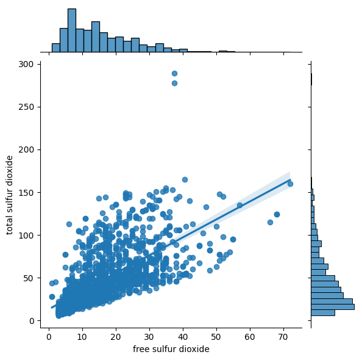

```python
# create a jointgrid-based plot (regplot and histplot)
g = sns.JointGrid(data=wine,x='free sulfur dioxide',y='total sulfur dioxide')
g = g.plot(sns.regplot, sns.histplot)
```

#### Challenge: Create a regression model with "total sulfur dioxide" as the dependent variable and "free sulfur dioxide" as the predictor variable.

Report the following:

1. Coefficient of determination (i.e. $r^2$)
2. Whether the regression is statistically significant
3. An estimate for the value of "total sulfur dioxide" when the value of "free sulfur dioxide" is 60.

```python
model1 = smf.ols("Q('total sulfur dioxide') ~ Q('free sulfur dioxide')", data=wine).fit()
model1.summary()
```

OLS Regression Results

| Dep. Variable: | Q('total sulfur dioxide') | R-squared: | 0.446 |
| --- | --- | --- | --- |
| Model: | OLS | Adj. R-squared: | 0.445 |
| Method: | Least Squares | F-statistic: | 1285. |
| Date: | Thu, 26 Sep 2024 | Prob (F-statistic): | 6.40e-207 |
| Time: | 15:35:42 | Log-Likelihood: | -7382.4 |
| No. Observations: | 1599 | AIC: | 1.477e+04 |
| Df Residuals: | 1597 | BIC: | 1.478e+04 |
| Df Model: | 1 |  |  |
| Covariance Type: | nonrobust |  |  |

|  | coef | std err | t | P>\|t\| | [0.025 | 0.975] |
| --- | --- | --- | --- | --- | --- | --- |
| Intercept | 13.1354 | 1.114 | 11.795 | 0.000 | 10.951 | 15.320 |
| Q('free sulfur dioxide') | 2.0997 | 0.059 | 35.840 | 0.000 | 1.985 | 2.215 |

| Omnibus: | 621.223 | Durbin-Watson: | 1.553 |
| --- | --- | --- | --- |
| Prob(Omnibus): | 0.000 | Jarque-Bera (JB): | 3163.294 |
| Skew: | 1.767 | Prob(JB): | 0.00 |
| Kurtosis: | 8.915 | Cond. No. | 34.6 |

Notes:  
[1] Standard Errors assume that the covariance matrix of the errors is correctly specified.

The coefficient of determination $r^2$ is 0.446, indicating our model explains 44.6% of the variance in `total sulfur dioxide`. The model is statistically significant, as the p-value for the $F$-statistic is less than 0.05.

```python
# predict
model1.predict(pd.DataFrame({'free sulfur dioxide': [60]}))
```

```
0    139.116852
dtype: float64
```

### ANOVA

For this section, we draw our inspiration from the FiveThirtyEight article [*“‘Straight Outta Compton’ Is The Rare Biopic Not About White Dudes”*](https://fivethirtyeight.com/features/straight-outta-compton-is-the-rare-biopic-not-about-white-dudes/).

FiveThirtyEight has a great habit of publishing the data that underpin their stories. These data are available via GitHub, making it easy to load them into a DataFrame:

```python
url = "https://raw.githubusercontent.com/fivethirtyeight/data/master/biopics/biopics.csv"
```

```python
biopics = pd.read_csv(url,encoding="latin1")
```

```python
biopics.head()
```

|  | title | site | country | year_release | box_office | director | number_of_subjects | subject | type_of_subject | race_known | subject_race | person_of_color | subject_sex | lead_actor_actress |
| --- | --- | --- | --- | --- | --- | --- | --- | --- | --- | --- | --- | --- | --- | --- |
| 0 | 10 Rillington Place | http://www.imdb.com/title/tt0066730/ | UK | 1971 | - | Richard Fleischer | 1 | John Christie | Criminal | Unknown | NaN | 0 | Male | Richard Attenborough |
| 1 | 12 Years a Slave | http://www.imdb.com/title/tt2024544/ | US/UK | 2013 | $56.7M | Steve McQueen | 1 | Solomon Northup | Other | Known | African American | 1 | Male | Chiwetel Ejiofor |
| 2 | 127 Hours | http://www.imdb.com/title/tt1542344/ | US/UK | 2010 | $18.3M | Danny Boyle | 1 | Aron Ralston | Athlete | Unknown | NaN | 0 | Male | James Franco |
| 3 | 1987 | http://www.imdb.com/title/tt2833074/ | Canada | 2014 | - | Ricardo Trogi | 1 | Ricardo Trogi | Other | Known | White | 0 | Male | Jean-Carl Boucher |
| 4 | 20 Dates | http://www.imdb.com/title/tt0138987/ | US | 1998 | $537K | Myles Berkowitz | 1 | Myles Berkowitz | Other | Unknown | NaN | 0 | Male | Myles Berkowitz |

We're interested in the 'box_office' variable, which is an oddly-formatted representation of the box-office earnings for each movie. We're going to create a function that converts representations like '$56.7M' to '56700000'. How?

#### 🚀 Challenge:

Write a function called `convert_box_office` that takes a string as input and returns a float. The function should:

1. Remove the dollar sign (`$`)
2. Remove the 'M' (million) or 'K' (thousand) at the end of the string
3. Convert the string to a float
4. Multiply the float by:
   - 1,000,000 if there was an 'M' at the end of the string
   - 1,000 if there was a 'K' at the end of the string
5. Return the result, or return a `NaN` if the input is not a valid box office revenue value.

You may find the `re` library helpful for this task... or not. 😉

```python
import re

def box_office_dollars(earnings):
    """Process the dollar variables in the earnings column"""
    if earnings == "-":
        return np.nan
    elif earnings[-1] == "K":
        return float(earnings[1:-1]) * 1000
    elif earnings[-1] == "M":
        return float(earnings[1:-1]) * 1000000
    else:
        return float(earnings[1:])

# Test out your function using assert statements
assert(box_office_dollars("$1") == 1.0)
assert(box_office_dollars("$537K") == 537000.0)
assert(box_office_dollars("$1M") == 1000000.0)
assert(np.isnan(box_office_dollars("-")))
```

And apply it to our DataFrame, creating a new column called 'box_office_dollars'

```python
biopics['box_office_dollars'] = biopics['box_office'].apply(box_office_dollars)
```

```python
biopics.head()
```

|  | title | site | country | year_release | box_office | director | number_of_subjects | subject | type_of_subject | race_known | subject_race | person_of_color | subject_sex | lead_actor_actress | box_office_dollars |
| --- | --- | --- | --- | --- | --- | --- | --- | --- | --- | --- | --- | --- | --- | --- | --- |
| 0 | 10 Rillington Place | http://www.imdb.com/title/tt0066730/ | UK | 1971 | - | Richard Fleischer | 1 | John Christie | Criminal | Unknown | NaN | 0 | Male | Richard Attenborough | NaN |
| 1 | 12 Years a Slave | http://www.imdb.com/title/tt2024544/ | US/UK | 2013 | $56.7M | Steve McQueen | 1 | Solomon Northup | Other | Known | African American | 1 | Male | Chiwetel Ejiofor | 56700000.0 |
| 2 | 127 Hours | http://www.imdb.com/title/tt1542344/ | US/UK | 2010 | $18.3M | Danny Boyle | 1 | Aron Ralston | Athlete | Unknown | NaN | 0 | Male | James Franco | 18300000.0 |
| 3 | 1987 | http://www.imdb.com/title/tt2833074/ | Canada | 2014 | - | Ricardo Trogi | 1 | Ricardo Trogi | Other | Known | White | 0 | Male | Jean-Carl Boucher | NaN |
| 4 | 20 Dates | http://www.imdb.com/title/tt0138987/ | US | 1998 | $537K | Myles Berkowitz | 1 | Myles Berkowitz | Other | Unknown | NaN | 0 | Male | Myles Berkowitz | 537000.0 |

#### 🚀 Challenge: What Should We Do with Our Missing Values?

Dealing with missing values is an important part of data cleaning. Consider the strategies you could apply to handle missing values effectively in your dataset.

```python
# get rid of all the rows with missing box office values
biopics.dropna(subset=['box_office_dollars'], inplace=True)
```

As always, let's take a look at the distribution of our variable:

```python
biopics['box_office_dollars'].describe()
```

```
count    4.370000e+02
mean     2.298117e+07
std      3.831136e+07
min      3.150000e+03
25%      1.170000e+06
50%      6.140000e+06
75%      3.050000e+07
max      3.500000e+08
Name: box_office_dollars, dtype: float64
```

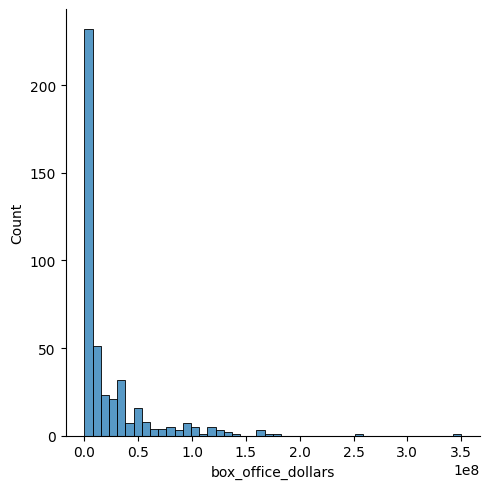

```python
sns.displot(biopics['box_office_dollars'])
```

Hmmmm. That doesn't look quite right (why? 🤔). Heavily right skewed

Let's see if we can make that resemble a normal distribution. We'll try applying a **log transform** to the data:

```python
biopics['log_box_office_dollars'] = np.log(biopics['box_office_dollars'])
```

```python
biopics.head()
```

|  | title | site | country | year_release | box_office | director | number_of_subjects | subject | type_of_subject | race_known | subject_race | person_of_color | subject_sex | lead_actor_actress | box_office_dollars | log_box_office_dollars |
| --- | --- | --- | --- | --- | --- | --- | --- | --- | --- | --- | --- | --- | --- | --- | --- | --- |
| 1 | 12 Years a Slave | http://www.imdb.com/title/tt2024544/ | US/UK | 2013 | $56.7M | Steve McQueen | 1 | Solomon Northup | Other | Known | African American | 1 | Male | Chiwetel Ejiofor | 56700000.0 | 17.853285 |
| 2 | 127 Hours | http://www.imdb.com/title/tt1542344/ | US/UK | 2010 | $18.3M | Danny Boyle | 1 | Aron Ralston | Athlete | Unknown | NaN | 0 | Male | James Franco | 18300000.0 | 16.722412 |
| 4 | 20 Dates | http://www.imdb.com/title/tt0138987/ | US | 1998 | $537K | Myles Berkowitz | 1 | Myles Berkowitz | Other | Unknown | NaN | 0 | Male | Myles Berkowitz | 537000.0 | 13.193753 |
| 5 | 21 | http://www.imdb.com/title/tt0478087/ | US | 2008 | $81.2M | Robert Luketic | 1 | Jeff Ma | Other | Known | Asian American | 1 | Male | Jim Sturgess | 81200000.0 | 18.212426 |
| 6 | 24 Hour Party People | http://www.imdb.com/title/tt0274309/ | UK | 2002 | $1.13M | Michael Winterbottom | 1 | Tony Wilson | Musician | Known | White | 0 | Male | Steve Coogan | 1130000.0 | 13.937728 |

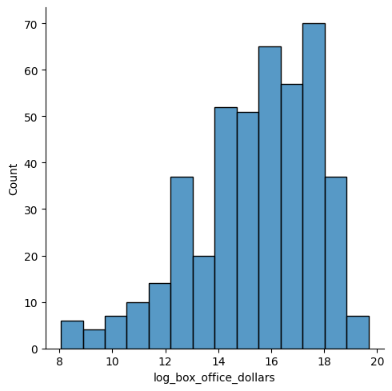

```python
sns.displot(biopics['log_box_office_dollars'])
```

#### 🚀 Challenge:

Use a **boxplot** to examine the relationship between `log(box_office_dollars)` and whether the subject of the biopic was a person of color or not.

Does it look like there’s a difference between the two groups?

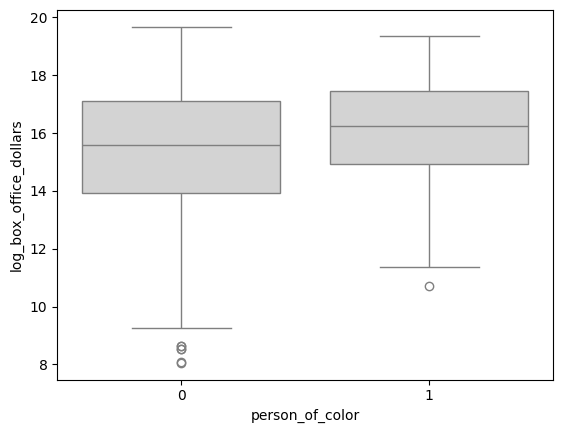

```python
# draw a boxplot to show the relationship between log box office dollars and
# whether the subject of biopic was a person of color or not

sns.boxplot(x="person_of_color",y="log_box_office_dollars", data=biopics, color = "lightgray")
```

The boxplot suggests there is a small difference of the log box office dollars between the two groups. The box office dollars for biopics whose subjects are person of color is slightly higher than those whose subjects are not.

```python
# Test with regression
model = smf.ols("log_box_office_dollars ~ person_of_color", data=biopics).fit()
model.summary()
```

OLS Regression Results

| Dep. Variable: | log_box_office_dollars | R-squared: | 0.009 |
| --- | --- | --- | --- |
| Model: | OLS | Adj. R-squared: | 0.007 |
| Method: | Least Squares | F-statistic: | 4.127 |
| Date: | Thu, 26 Sep 2024 | Prob (F-statistic): | 0.0428 |
| Time: | 15:35:42 | Log-Likelihood: | -984.42 |
| No. Observations: | 437 | AIC: | 1973. |
| Df Residuals: | 435 | BIC: | 1981. |
| Df Model: | 1 |  |  |
| Covariance Type: | nonrobust |  |  |

|  | coef | std err | t | P>\|t\| | [0.025 | 0.975] |
| --- | --- | --- | --- | --- | --- | --- |
| Intercept | 15.2572 | 0.121 | 125.644 | 0.000 | 15.018 | 15.496 |
| person_of_color | 0.5915 | 0.291 | 2.031 | 0.043 | 0.019 | 1.164 |

| Omnibus: | 34.714 | Durbin-Watson: | 1.793 |
| --- | --- | --- | --- |
| Prob(Omnibus): | 0.000 | Jarque-Bera (JB): | 41.072 |
| Skew: | -0.745 | Prob(JB): | 1.21e-09 |
| Kurtosis: | 3.182 | Cond. No. | 2.73 |

Notes:  
[1] Standard Errors assume that the covariance matrix of the errors is correctly specified.

## The t-test

To test if there’s a statistically significant difference between **two** means, we can use the **independent sample t-test**.

First, let’s load the appropriate package:

```python
from scipy.stats import ttest_ind
```

It's more readable if we split the data into two samples:

```python
poc = biopics[biopics["person_of_color"] == 1]
not_poc = biopics[biopics["person_of_color" ] == 0]
```

```python
ttest_ind(poc["log_box_office_dollars"],not_poc["log_box_office_dollars"])
```

```
TtestResult(statistic=np.float64(2.0314176362558167), pvalue=np.float64(0.042820052741479), df=np.float64(435.0))
```

#### 🚀 Challenge: What Does That Mean?

After performing the t-test, what can we infer from the result? Does it suggest a statistically significant difference between the two means? Interpret the findings.

Yes. The $t$-statistic is 2.03 with a $p$-value of 0.04, which is slightly less than 0.05. This suggests that there is a statistically significant difference between the two means.

Things get a bit more complicated when we have more than two groups. While we could perform multiple t-tests, that’s not a great idea (why? 🤔).

Instead, we can use **ANOVA** to test if there are any differences between the group means. If we find significant differences, we can then apply **Tukey's HSD** to determine which groups differ from each other.

```python
biopics.subject_race.value_counts().sort_index()
```

```
subject_race
African                        7
African American              31
Asian                          4
Asian American                 3
Caribbean                      1
Hispanic (Latin American)     10
Hispanic (Latina)              1
Hispanic (Latino)              4
Hispanic (White)               4
Indian                         1
Mediterranean                  1
Middle Eastern                 5
Middle Eastern (White)         8
Multi racial                  17
Native American                2
White                        218
Name: count, dtype: int64
```

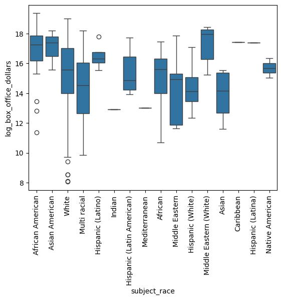

```python
sns.boxplot(x="subject_race",y="log_box_office_dollars",data=biopics)
_ = plt.xticks(rotation=90)
```

It looks like there may be some differences between the different groups. But are they real?

#### 🚀 Challenge:

Use **ANOVA** to test if there are any differences between the means of the different groups.

If you find significant differences, apply **Tukey's HSD** to determine which groups are different from each other.

```python
# Test the differences across groups with ANOVA
model_race = smf.ols("log_box_office_dollars ~ subject_race", data=biopics).fit()
model_anova = sm.stats.anova_lm(model_race, typ=2)
model_anova
```

|  | sum_sq | df | F | PR(>F) |
| --- | --- | --- | --- | --- |
| subject_race | 182.728250 | 15.0 | 2.566995 | 0.001263 |
| Residual | 1428.419809 | 301.0 | NaN | NaN |

There is at least one significant difference in the mean log box office dollars between the groups.

```python
# Check the differences between each pair of groups with Tukey's HSD
biopics.dropna(subset=['subject_race'], inplace=True)
hsd = pairwise_tukeyhsd(biopics['log_box_office_dollars'], biopics['subject_race'])
hsd.summary()
```

Multiple Comparison of Means - Tukey HSD, FWER=0.05

| group1 | group2 | meandiff | p-adj | lower | upper | reject |
| --- | --- | --- | --- | --- | --- | --- |
| African | African American | 1.9884 | 0.7096 | -1.1616 | 5.1384 | False |
| African | Asian | -1.0387 | 1.0 | -5.7568 | 3.6794 | False |
| African | Asian American | 2.1526 | 0.9884 | -3.0419 | 7.347 | False |
| African | Caribbean | 2.517 | 0.9995 | -5.5302 | 10.5642 | False |
| African | Hispanic (Latin American) | 0.4535 | 1.0 | -3.2561 | 4.1631 | False |
| African | Hispanic (Latina) | 2.4782 | 0.9996 | -5.569 | 10.5254 | False |
| African | Hispanic (Latino) | 1.5807 | 0.9988 | -3.1374 | 6.2988 | False |
| African | Hispanic (White) | -0.4918 | 1.0 | -5.2099 | 4.2263 | False |
| African | Indian | -2.0048 | 1.0 | -10.052 | 6.0424 | False |
| African | Mediterranean | -1.896 | 1.0 | -9.9432 | 6.1512 | False |
| African | Middle Eastern | -0.577 | 1.0 | -4.9847 | 3.8306 | False |
| African | Middle Eastern (White) | 2.4058 | 0.7418 | -1.4901 | 6.3016 | False |
| African | Multi racial | -0.6743 | 1.0 | -4.0548 | 2.7062 | False |
| African | Native American | 0.7853 | 1.0 | -5.2502 | 6.8207 | False |
| African | White | 0.3095 | 1.0 | -2.581 | 3.1999 | False |
| African American | Asian | -3.0271 | 0.3919 | -7.0263 | 0.9721 | False |
| African American | Asian American | 0.1642 | 1.0 | -4.3872 | 4.7156 | False |
| African American | Caribbean | 0.5286 | 1.0 | -7.1193 | 8.1765 | False |
| African American | Hispanic (Latin American) | -1.5349 | 0.8564 | -4.2724 | 1.2027 | False |
| African American | Hispanic (Latina) | 0.4898 | 1.0 | -7.1581 | 8.1377 | False |
| African American | Hispanic (Latino) | -0.4077 | 1.0 | -4.4068 | 3.5915 | False |
| African American | Hispanic (White) | -2.4801 | 0.7357 | -6.4793 | 1.519 | False |
| African American | Indian | -3.9932 | 0.9133 | -11.6411 | 3.6547 | False |
| African American | Mediterranean | -3.8843 | 0.9298 | -11.5323 | 3.7636 | False |
| African American | Middle Eastern | -2.5654 | 0.5164 | -6.1931 | 1.0623 | False |
| African American | Middle Eastern (White) | 0.4174 | 1.0 | -2.5677 | 3.4025 | False |
| African American | Multi racial | -2.6627 | 0.0064 | -4.9344 | -0.3909 | True |
| African American | Native American | -1.2031 | 1.0 | -6.6949 | 4.2886 | False |
| African American | White | -1.6789 | 0.0073 | -3.1238 | -0.234 | True |
| Asian | Asian American | 3.1913 | 0.8657 | -2.558 | 8.9405 | False |

[output cut: 90 more lines]

#### 🚀 Challenge:

Is there a **statistically significant difference** between the groups?

Which groups are different from which other groups? Use the results from ANOVA and Tukey's HSD to answer these questions.

The African-American group is significantly different from the White group and the multi-race group as the two null hypotheses are rejected at 95% confidence level.

#### 🚀 Optional Challenge:

Download the chocolate bars rating dataset from [Kaggle](https://www.kaggle.com/rtatman/chocolate-bar-ratings).

Use the data to answer the following questions:

1. Is there a **statistically significant difference** in the average rating of chocolate bars from different countries (using the country of manufacture)? If yes, which countries are different from each other?
2. Explore other variables in the dataset. Can you find anything else interesting?

Feel free to use as many code and markdown cells as necessary to answer these questions.

## 🏁 **END OF NOTEBOOK**

### 📥 **Remember to submit** this file in **HTML** and **IPYNB** formats via Canvas.